# Quests vs. Death Knights vs. Legendary Weapons

Its been a year of Mammoth proportions, with no less than 54 class legendaries being released! Half of these have been built up as the marquee content of each update, with Blizzard cranking up the hype-machine for Quests, Death Knights and Legendary Weapons during their respective pre-launch windows. If you have been living under a rock for the past year, here are the three new types of legendary introduced this year:

- **Quests**: Released with Journey to Un’Goro, these legendary spells start in your hand and require you to fulfill a set of conditions for a big reward.
- **Death Knights**: Released with Knight of the Frozen Throne, these playable heroes replace your starting hero, Jarraxxus style.
- **Legendary Weapons**: Just released in Kobolds and Catacombs, well, their weapons but legendary…

Now that the year of the mammoth is in its twilight, it seems natural to ask the question of which set had the biggest impact on the meta during their respective launch windows, and what do they look like now? The following constitutes somewhat of a Quests vs. Death Knights vs. Legendary weapons ultimate showdown!

## Play Rates

During the launch week of an expansion, its reasonable to expect elevated play rates for marquee content, even if win-rates aren’t optimal. By looking at play-rates, we get a snapshot into the immediate impact the content had on the meta, before its ‘figured out’ and everybody starts playing serious decks again. The following shows the overall proportion of decks that include the marquee Legendaries during by expansion windows for the first 7 days of launch.

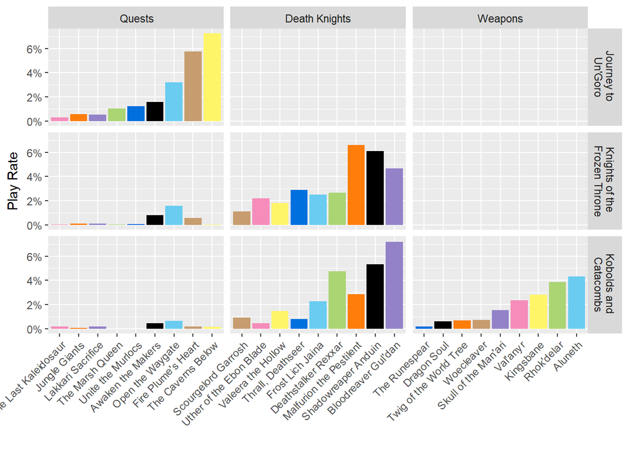

**Figure 1: Play Rate in the initial 1-week window post-launch by expansion and marquee legendary type.**

The data shows that during their respective launch windows, each of the marquee legendary sets saw a significant amount of play. There is stark contrast however between the popularity of Quests and Death Knights in their post-launch launch windows. Quests have seen basically no play since Knights of the Frozen Throne launched but Death Knights were actually played more than Legendary weapons during the Kobolds and Catacombs launch window. Its fair to say legendary weapons have had the least immediate impact of all 3 releases, at least in terms of play-rates.

As time has passed, the only Quest that saw over 1% of play was Open the Waygate, with the OTK Mage deck seeing viability in the Druid control dominated meta we saw early days into Knights of the Frozen Throne. But with Kobolds and Catacombss launch, the quest is no longer required to OTK and its popularity has taken another hit. The biggest winners in terms of Death Knights have been Deathstalker Rexxar and Bloodreaver Guldan, with plenty of tools for Control Warlock and Minion-less Hunter decks being introduced in Kobolds and Catacombs.

## Win Rates

Of course, play-rates only tell part of the story with win-rates dictating to some extend the cards that people like to play (even in launch week). The following shows the initial win-rates of the marquee cards.

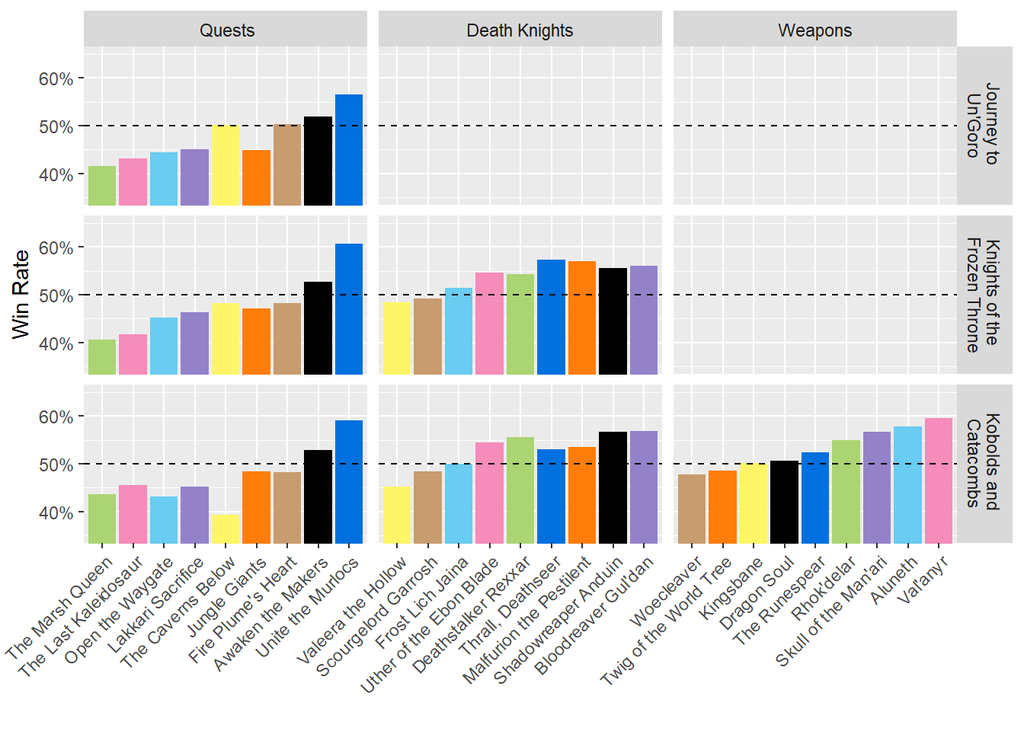

**Figure 2: Win Rate in the initial 1-week window post-launch by expansion and marquee legendary type.**

First of all, for those interested in “the best” legendary weapons, Val’anyr, Aluneth, Skull of the Man’ari and Rhok’delar have found decks and archetypes with a lot of play data to support the positive win-rates, and make for good crafts if you really want a legendary weapon.

With respect to initial win-rates, Quests clearly took longer to refine than Death Knights and Legendary Weapon lists. In the initial week, 5/9 quests had sub 50% win-rates, with the most played (The caverns Below & Fire Plumes Heart) having near 50% win rates. Death Knights and Legendary weapons on the other hand have the vast majority being viable even in the first week. A similar trend is observed for Legendary Weapons. You could argue the later two card types are easier to fit into existing decks, making them much easier to find a place in the early meta.

So to sum up, many have questioned the fundamental viability of quests, with many suggesting that sacrificing a card in your opening hand is just too higher cost to ever be viable, particularly in the seemingly everlasting aggro meta that Hearthstone seems to exist in. Death Knights on the other hand are as popular as ever, even more so than Legendary Weapons

In the epic battle between Quests, Death Knights and Legendary Weapons, Death Knights come up as the obvious winner, not only for their initial impact but their lasting success. The final question, which cant be answered with data, is whats better for the game? Should marquee content by pushed aside (more variety in the meta) or should it stick around (better value for crafts)?